# 政治学方法論 I：ロジスティック回帰とプロビット回帰

矢内 勇生

December 24, 2014

## 準備

coefplotとggplot2を読み込んでおく。

```r
require(coefplot)
require(ggplot2)
## Mac で日本語を使う場合、以下のコメントを外して実行
# theme_set(theme_gray(base_size=12, base_family="HiraKakuProN-W3"))
```

ロジット関数の逆関数を作成しておく。

```r
invlogit <- function(x){
    p <- 1 / (1 + exp(-x))
    return(p)
}
```

## ロジスティック（ロジット）回帰

### データの読み込み

[浅野・矢内 (2013)](http://www2.kobe-u.ac.jp/~yyanai/jp/quant-methods-stata/) に登場する衆院選選挙区データ（hr96-09.dta）を利用して説明する。

このデータのうち、小選挙区での勝敗を説明するロジスティック回帰モデルを考える。

まず、使用するデータを読み込む。

```r
require(foreign)
myd <- read.dta("data/hr96-09.dta")
head(myd)
```

```
##   year    ku kun party              name age     status nocand   wl rank
## 1 1996 aichi   1   NFP KAWAMURA, TAKASHI  47  incumbent      7  win    1
## 2 1996 aichi   1   LDP     IMAEDA, NORIO  72       moto      7 lose    2
## 3 1996 aichi   1   DPJ     SATO, TAISUKE  53  incumbent      7 lose    3
## 4 1996 aichi   1   JCP   IWANAKA, MIHOKO  43 challenger      7 lose    4
## 5 1996 aichi   1 bunka       ITO, MASAKO  51 challenger      7 lose    5
## 6 1996 aichi   1    NP  YAMADA, HIROSHIB  51 challenger      7 lose    6
##   previous  vote voteshare eligible turnout     exp
## 1        2 66876      40.0   346774   49.22 9828097
## 2        3 42969      25.7   346774   49.22 9311555
## 3        2 33503      20.1   346774   49.22 9231284
## 4        0 22209      13.3   346774   49.22 2177203
## 5        0   616       0.4   346774   49.22      NA
## 6        0   566       0.3   346774   49.22      NA
```

このデータセットには、小選挙区での選挙結果を表すwlという変数が含まれている。 この変数の値は、“win”（勝ち）、“lose”（負け）、“zombie” （復活当選）の3種類であり、値が文字列で与えられている。この変数を元に、勝ちなら1、負けなら0を取る二値変数、wlsmd を作ろう。

```r
myd$wlsmd <- as.numeric(myd$wl=="win")
with(myd, table(wlsmd))
```

```
## wlsmd
##    0    1
## 4114 1500
```

また、選挙費用を1円単位で測定したexpを元に、費用を百万円単位で測るexpmを作る。

```r
myd$expm <- myd$exp / 10^6
```

自民党、公明党、民主党を示すダミー変数を作る。

```r
myd$LDP <- as.numeric(myd$party=="LDP")
myd$Komei <- as.numeric(myd$party=="CGP")
myd$DPJ <- as.numeric(myd$party=="DPJ")
```

説明を単純化するため、分析対象を2009年衆院選に限定し、欠測値を（とりあえず）消しておく。

```r
myd.2009 <- na.omit(subset(myd, year==2009))
```

### 回帰式の当てはめ

このデータを使い、小選挙区での勝敗を、過去の当選回数 previous と選挙費用 expm で説明するモデルを考える（実際の分析では、説明変数と応答変数の間にどのような理論的な関係があるかを明らかにすべきである。言い換えると、説明変数の選択は理論に基づいて行うべきである。ここでは、分析手法の説明に集中するため、理論は考えない [以下の問題も同様]）。 このモデルのロジスティック回帰式は、次のように求めることができる。

```r
fit.logit.1 <- glm(wlsmd ~ previous + expm, data=myd.2009,
                   family=binomial(link="logit"))
summary(fit.logit.1)
```

```
##
## Call:
## glm(formula = wlsmd ~ previous + expm, family = binomial(link = "logit"),
##     data = myd.2009)
##
## Deviance Residuals:
##    Min      1Q  Median      3Q     Max
## -3.069  -0.592  -0.511   0.522   1.974
##
## Coefficients:
##             Estimate Std. Error z value Pr(>|z|)
## (Intercept)  -2.0375     0.1330  -15.32   <2e-16
## previous      0.3605     0.0383    9.42   <2e-16
## expm          0.0382     0.0184    2.08    0.038
##
## (Dispersion parameter for binomial family taken to be 1)
##
##     Null deviance: 1300.1  on 1123  degrees of freedom
## Residual deviance: 1071.7  on 1121  degrees of freedom
## AIC: 1078
##
## Number of Fisher Scoring iterations: 4
```

この結果は、 $\mbox{当選確率} = \frac{1}{1 + \exp[-(-2.04 + 0.36 \mbox{当選回数} + 0.04\mbox{選挙費用})]}$ ということを示している。

次に、説明変数に候補者の年齢 age を加えて回帰式を求めてみよう。

```r
fit.logit.2 <- glm(wlsmd ~ previous + expm + age , data=myd.2009,
                   family=binomial(link="logit"))
summary(fit.logit.2)
```

```
##
## Call:
## glm(formula = wlsmd ~ previous + expm + age, family = binomial(link = "logit"),
##     data = myd.2009)
##
## Deviance Residuals:
##    Min      1Q  Median      3Q     Max
## -3.209  -0.660  -0.441   0.476   2.286
##
## Coefficients:
##             Estimate Std. Error z value Pr(>|z|)
## (Intercept)  0.76684    0.38748    1.98    0.048
## previous     0.51728    0.04673   11.07  < 2e-16
## expm         0.04477    0.01916    2.34    0.019
## age         -0.06454    0.00882   -7.32  2.5e-13
##
## (Dispersion parameter for binomial family taken to be 1)
##
##     Null deviance: 1300.1  on 1123  degrees of freedom
## Residual deviance: 1012.1  on 1120  degrees of freedom
## AIC: 1020
##
## Number of Fisher Scoring iterations: 5
```

この結果は、 $\mbox{当選確率} = \frac{1}{1 + \exp[-(0.77 + 0.52 \mbox{当選回数} + 0.04\mbox{選挙費用} -0.06\mbox{年齢})]}$ ということを示している。

さらに、自民党、公明党、民主党を表すダミー変数を説明変数に加える。

```r
fit.logit.3 <- glm(wlsmd ~ previous + expm + age + LDP + Komei + DPJ,
                   data=myd.2009, family=binomial(link="logit"))
summary(fit.logit.3)
```

```
##
## Call:
## glm(formula = wlsmd ~ previous + expm + age + LDP + Komei + DPJ,
##     family = binomial(link = "logit"), data = myd.2009)
##
## Deviance Residuals:
##    Min      1Q  Median      3Q     Max
## -2.882  -0.265  -0.191   0.241   2.799
##
## Coefficients:
##             Estimate Std. Error z value Pr(>|z|)
## (Intercept)  -2.4980     0.6300   -3.97  7.3e-05
## previous      0.4845     0.0577    8.40  < 2e-16
## expm          0.0401     0.0304    1.32   0.1871
## age          -0.0332     0.0126   -2.64   0.0083
## LDP           0.4533     0.4278    1.06   0.2893
## Komei       -14.3561   589.2697   -0.02   0.9806
## DPJ           4.1893     0.3399   12.32  < 2e-16
##
## (Dispersion parameter for binomial family taken to be 1)
##
##     Null deviance: 1300.13  on 1123  degrees of freedom
## Residual deviance:  584.78  on 1117  degrees of freedom
## AIC: 598.8
##
## Number of Fisher Scoring iterations: 14
```

（式は省略：自分で考えてみよう。）

### 当てはまり具合の確認

これらの3つのモデルを比較すると、3つ目のモデルのAICが1番小さい。 したがって、3つ目のモデルの説明力が一番高いことがわかる。

それぞれのモデルの予測的中率を求めてみよう。 当選確率が0.5より大きいのものを当選、0.5より小さいものを落選（0.5の場合はどちらでもよい）としたときの予測の的中率を求めてみよう。 まず、`predict()`を使って予測確率を求める。

```r
myd.2009$pred.1 <- predict(fit.logit.1, type="response")
myd.2009$pred.2 <- predict(fit.logit.2, type="response")
myd.2009$pred.3 <- predict(fit.logit.3, type="response")
```

この予測確率を使い、予測の的中率を求める。

```r
ert.1 <- with(myd.2009, mean((pred.1 > 0.5 & wlsmd==0) | (pred.1 < 0.5 & wlsmd==1)))
ert.2 <- with(myd.2009, mean((pred.2 > 0.5 & wlsmd==0) | (pred.2 < 0.5 & wlsmd==1)))
ert.3 <- with(myd.2009, mean((pred.3> 0.5 & wlsmd==0) | (pred.3 < 0.5 & wlsmd==1)))
1 - c(ert.1, ert.2, ert.3)
```

```
## [1] 0.7464 0.7705 0.8826
```

モデル3の的中率が88%でもっとも高いことがわかる。

実際に観測された当選割合は、

```r
with(myd.2009, mean(wlsmd))
```

```
## [1] 0.2651
```

だから、

```r
1 - with(myd.2009, mean(wlsmd))
```

```
## [1] 0.7349
```

が予測の基準である（「全員落選」と予測すれば、73%は的中する）。 モデル1とモデル2の予測は、単に平均値を利用して予測する場合とほとんど変わらず、当てはまりが悪いことがわかる。それに対し、モデル3では的中率の改善が見られる。

続いて、3つのモデルのROC曲線を比較してみよう。 ここでは、真陽性率（感度）と偽陽性率（1-特異度）を計算する関数を自分で作り、ROC曲線を描いてみる

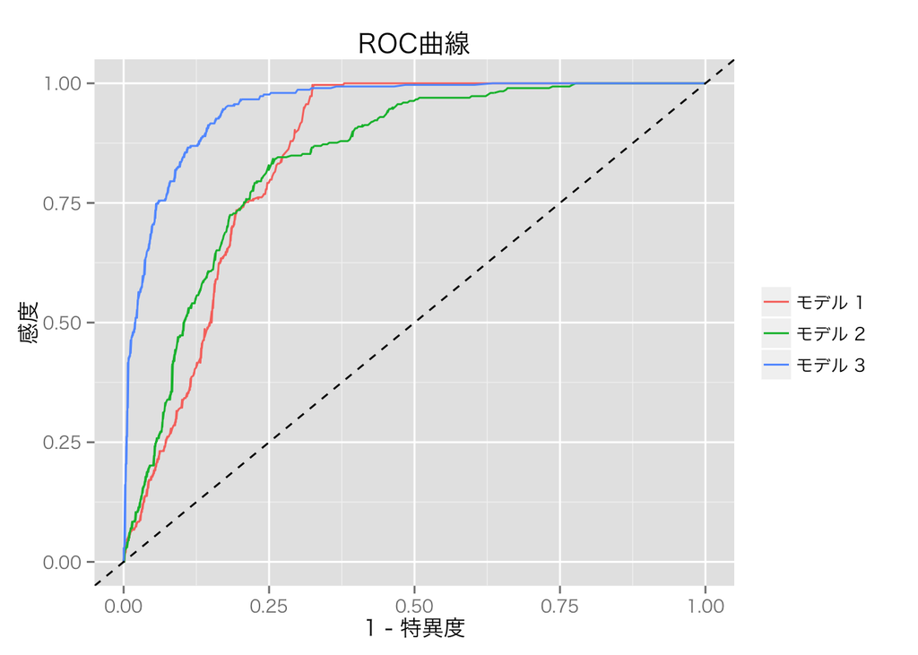

```r
## 真陽性率（感度）を計算する関数
true.pos <- function(predicted, observed, cutoff=0.5){
    n <- length(cutoff)
    res <- rep(NA, n)
    for(i in 1:n){
        res[i] <- mean(predicted>=cutoff[i] & observed==1)/mean(observed)
    }
    return(res)
}
## 偽陽性率（1-特異度）を計算する関数
false.pos <- function(predicted, observed, cutoff=.5){
    n <- length(cutoff)
    res <- rep(NA, n)
    for(i in 1:n){
        res[i] <- mean(predicted>=cutoff[i] & observed==0)/(1-mean(observed))
    }
    return(res)
}
## 成功と失敗の境界確率を0から1まで変化させ、感度と偽陽性率を計算する
cutoff.vec <- seq(0, 1, length=1000)
tp.1 <- true.pos(myd.2009$pred.1, myd.2009$wlsmd, cutoff=cutoff.vec)
tp.2 <- true.pos(myd.2009$pred.2, myd.2009$wlsmd, cutoff=cutoff.vec)
tp.3 <- true.pos(myd.2009$pred.3, myd.2009$wlsmd, cutoff=cutoff.vec)
fp.1 <- false.pos(myd.2009$pred.1, myd.2009$wlsmd, cutoff=cutoff.vec)
fp.2 <- false.pos(myd.2009$pred.2, myd.2009$wlsmd, cutoff=cutoff.vec)
fp.3 <- false.pos(myd.2009$pred.3, myd.2009$wlsmd, cutoff=cutoff.vec)
## ggplot2 でグラフを描くためのデータフレームを作る
df.roc <- data.frame(true.positive = c(tp.1, tp.2, tp.3),
                      false.positive = c(fp.1, fp.2, fp.3),
                      model = rep(c("model1", "model2", "model3"), rep(1000, 3)))
## ggplot でROC曲線を描く
p <- ggplot(df.roc, aes(x=false.positive, y=true.positive, color=model)) +
    geom_line() + geom_abline(intercept=0, slope=1, linetype="dashed") +
    scale_color_discrete(name="", labels=paste("モデル", 1:3)) +
    labs(x="1 - 特異度", y="感度", title="ROC曲線")
print(p)
```

この図からも、3つのモデルの中では3番目のモデルが最も当てはまりがよいことがわかる。

### 残差の検討

残差は、観測値と推定値の差なので、 $\mbox{残差}_i = y_i - \mathrm{logit}^{-1}({\bf x}_i^T {\bf \beta})$ で計算できる。 応答変数 $y_i$ が0または1の二値しかとらないので、特定の ${\bf x}_i^T {\bf \beta}$ に対する残差の値も2通りしかない。たとえば、$\mathrm{logit}^{-1}({\bf x}_i^T {\bf \beta})=0.4$ であれば、残差は$-0.4$と$0.6$の2通りしかない。

モデル3について残差を図にすると、次のようになる。

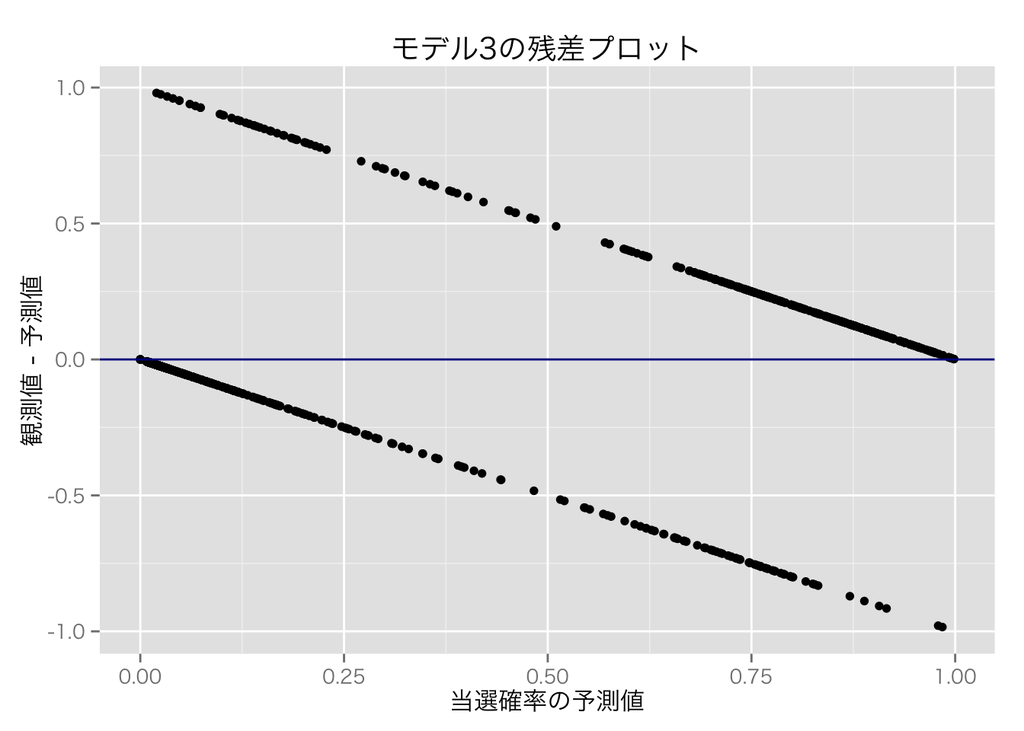

```r
myd.2009$res.3 <- with(myd.2009, wlsmd - pred.3)
res.p <- ggplot(myd.2009, aes(x=pred.3, y=res.3)) + geom_point() +
    geom_hline(yintercept=0, color="darkblue") +
    labs(x="当選確率の予測値", y="観測値 - 予測値", title="モデル3の残差プロット")
print(res.p)
```

このように、各予測値に対する残差の値が2種類しかないので、残差プロットは役に立たない。

そこで、グループ化した残差プロット (binned residual plot) を作る。 このプロットを作るためには、まず、予測値に応じて残差をグループ分けし、グループごとの平均残差を計算する。その後、横軸に各グループの平均予測値、縦軸に各グループの平均残差をプロットする。 モデル3について、このプロットを作ってみよう。

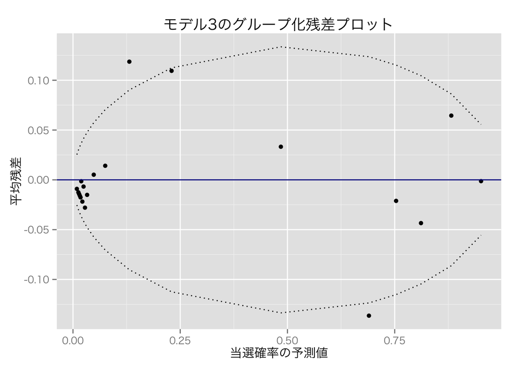

```r
## 予測値を20のグループに分ける：グループの数は恣意的
## 予測確率と残差を取り出す、データフレームdfを作る
df <- myd.2009[, c("pred.3", "res.3")]
## 予測確率が小さい順に並べ替える
df <- df[with(df, order(pred.3)),]
N <- dim(df)[1]      ## 観測値の数
df$group <- rep(20, N)     ## グループを示すカテゴリ変数を作る
n.group <- round(N/20)     ## グループごとの観測値の数を決める
## N/20 が割り切れない場合、最後のグループだけ数が異なる
## group 変数に値を入れる
df$group[1:(n.group*20)] <- rep(1:20, rep(n.group, 20))
## group ごとに予測値の平均と残差の平均を求める
## ggplotを使うためにデータフレーに入れる
df.group <- data.frame(pred.group = tapply(df$pred.3, df$group, mean),
                       res.group = tapply(df$res.3, df$group, mean),
                       n.group = tapply(df$res.3, df$group, length))
## +-2se を計算する
df.group$lb <- with(df.group, -2*sqrt(pred.group*(1-pred.group)/n.group))
df.group$ub <- with(df.group,  2*sqrt(pred.group*(1-pred.group)/n.group))

## プロットを作る
p.br <- ggplot(df.group, aes(x=pred.group, y=res.group)) + geom_point() +
    geom_line(aes(y=lb), linetype="dotted") +
    geom_line(aes(y=ub), linetype="dotted") +
    geom_hline(yintercept=0, color="darkblue") +
    labs(x="当選確率の予測値", y="平均残差",
         title="モデル3のグループ化残差プロット")
print(p.br)
```

この図はグループの数を20にした場合のグループ化残差プロットである。 グループの数は恣意的に決めた。 各グループに含まれる観測値の数が少なくなり過ぎないように選ぶべきである。 ここでは、観測値の数が、1124なので、1グループあたり56の観測値が含まれている。ただし、第20グループのみ60の観測値を含む。

この図を見る限り、残差に明確なパタンはなさそうである。 しかし、点の数が少ないので、あまりはっきりしたことはわからない （課題：グループの数を40に増やした場合の図を作って残差にパタンがないか確かめよ）。 上下に示されている点線は、$\pm2$se$=\pm 2\sqrt{p(1-p)/n}$ を示している（$p$はグループごとの予測確率、$n$はグループごとの観測値の数）。 この範囲に、およそ95%の点が含まれることが期待される。 この図では、20個中18個の点、つまり90％の点がこの範囲にあり、期待から大きく外れてはいない。

### 仮説検定

モデル3を使い、仮説検定の方法を説明する。 まず、切片を除く母数 $\beta_2, \dots, \beta_k$ について、$\beta_2 = \beta_3 = \cdots = \beta_k=0$という帰無仮説が与えられている場合について考える。 この仮説の検定は、deviance（逸脱度）を使って行う。 `summary(fit.logit.3)` の出力を見ると、**Null deviance** と**Residual deviance** が表示されている。前者がすべての母数（切片を除く）を0に設定したときのdeviance、後者が分析したモデルのdeviance である。Devianceが小さいモデルの方が良いモデルだと考えられる。 帰無仮説が正しければ、これら2つのdeviance の差が自由度 $\nu$ のカイ二乗分布に従う。ただし、 $\nu$は2つのdevianceの自由度の差（モデルに含まれる説明変数の数）である。 したがって、devianceの差に対してカイ二乗検定を行えばよい。

2つのdeviance の差と自由度の差は、

```r
X2.logit.3 <- with(fit.logit.3, null.deviance - deviance)
df.logit.3 <- with(fit.logit.3, df.null - df.residual)
```

で求められる。 これを使ってカイ二乗検定の$p$値を求めると、

```r
pchisq(X2.logit.3, df.logit.3, lower.tail=FALSE)
```

```
## [1] 2.97e-151
```

となる。これはほぼ0だから、有意水準0.01で帰無仮説 $\beta_2 = \beta_3 = \cdots = \beta_k=0$ は棄却される。

また、説明変数一つひとつの追加に意味があるかを確認するためには、変数を1つ加えるごとにdevianceがどれだけ減るかを確認する。応答変数に対して体系的な影響をもたないランダムな説明変数を加えると、deviance は（平均して）1だけ小さくなると期待される。したがって、説明変数の追加に意味があると主張するためには、説明変数1つの追加に対するdevianceの減少が1より著しく大きいことを示せばよい（検定するにはカイ二乗分布を利用する）。 `anova()` でこれを実行する。

```r
anova(fit.logit.3, test="Chi")
```

```
## Analysis of Deviance Table
##
## Model: binomial, link: logit
##
## Response: wlsmd
##
## Terms added sequentially (first to last)
##
##
##          Df Deviance Resid. Df Resid. Dev Pr(>Chi)
## NULL                      1123       1300
## previous  1    224.2      1122       1076  < 2e-16
## expm      1      4.2      1121       1072     0.04
## age       1     59.6      1120       1012  1.2e-14
## LDP       1    167.4      1119        845  < 2e-16
## Komei     1     36.2      1118        809  1.8e-09
## DPJ       1    223.8      1117        585  < 2e-16
```

この結果のうち、**Deviance**の列に、その変数を加えたことによってdeviance がどれだけ小さくなったかが示されている。どの変数についても、devianceの減少が1より大きいことがわかる。

次に、各係数について、「係数=0」という帰無仮説を検定してみよう。 各変数ごとに$p$値が示されており、この値を見れば仮説検定を実行することができる。 キャタピラプロットを使って確認してみよう。

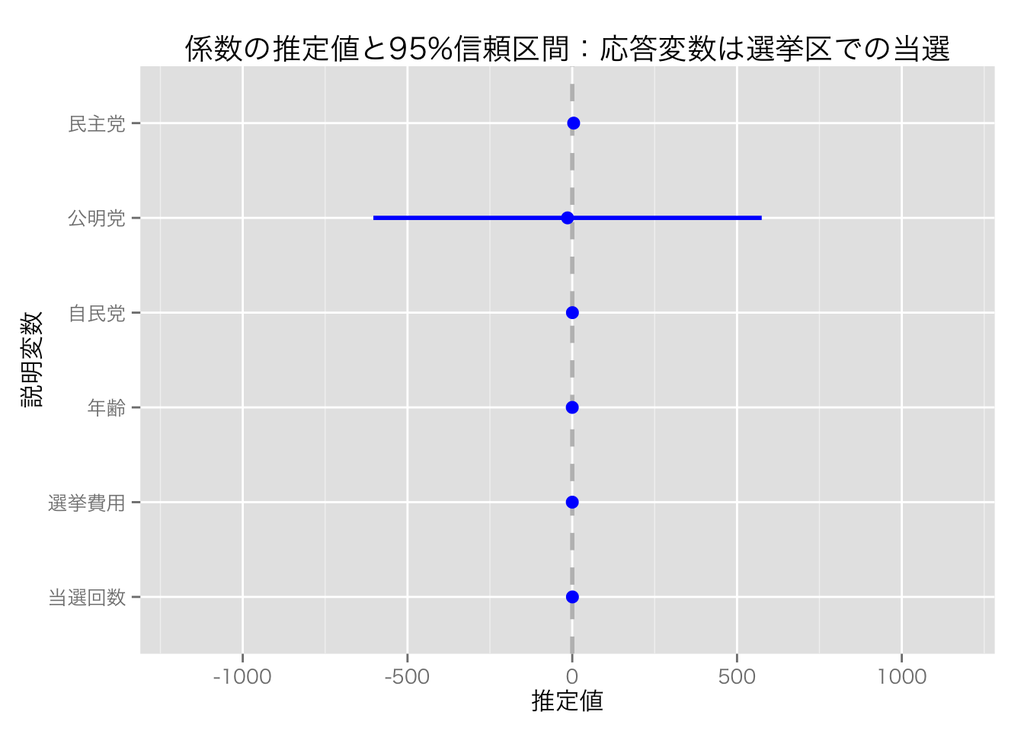

```r
coefNames = c(previous="当選回数", expm="選挙費用",
              age = "年齢", LDP="自民党",
              Komei="公明党", DPJ="民主党")
coefplot(fit.logit.3, intercept=FALSE, newNames=coefNames,
         xlab="推定値", ylab="説明変数",
         title="係数の推定値と95%信頼区間：応答変数は選挙区での当選")
```

この図から、公明党ダミーの効果が統計的に有意でないことがわかるので、公明党を除外して図を作り直してみよう。

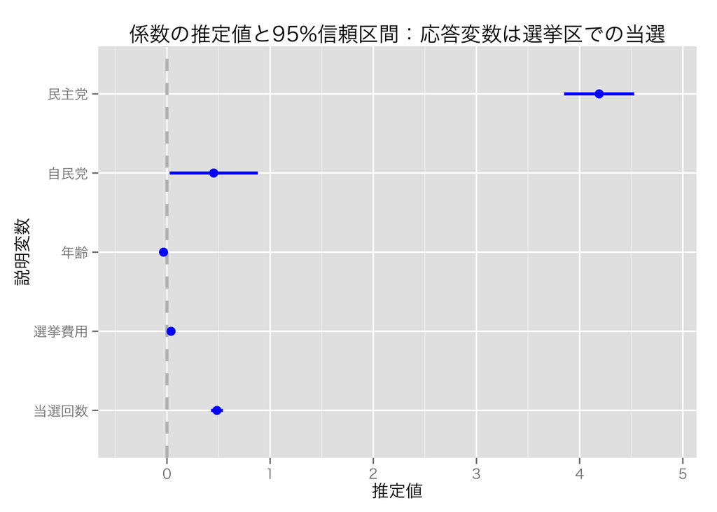

```r
coefplot(fit.logit.3, newNames=coefNames,
         coefficients=c("previous", "expm", "age", "LDP", "DPJ"),
         xlab="推定値", ylab="説明変数",
         title="係数の推定値と95%信頼区間：応答変数は選挙区での当選")
```

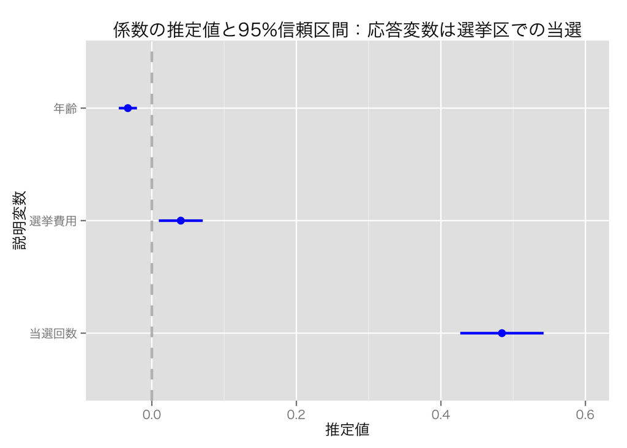

```r
coefplot(fit.logit.3, newNames=coefNames,
         coefficients=c("previous", "expm", "age"),
         xlab="推定値", ylab="説明変数",
         title="係数の推定値と95%信頼区間：応答変数は選挙区での当選")
```

### 推定結果の意味を考える

ロジスティック回帰の線形予測子と予測確率の関係は非線形なので、推定値の意味をそのまま解釈するのは難しい。そこで、各説明変数の値の特定の変化に対し、予測確率がどれだけ変化するかを考える。 説明を単純化するため、モデル2を使って考える。

モデル2の推定を再掲する。

```r
fit.logit.2 <- glm(wlsmd ~ previous + expm + age , data=myd.2009,
                   family=binomial(link="logit"))
summary(fit.logit.2)
```

```
##
## Call:
## glm(formula = wlsmd ~ previous + expm + age, family = binomial(link = "logit"),
##     data = myd.2009)
##
## Deviance Residuals:
##    Min      1Q  Median      3Q     Max
## -3.209  -0.660  -0.441   0.476   2.286
##
## Coefficients:
##             Estimate Std. Error z value Pr(>|z|)
## (Intercept)  0.76684    0.38748    1.98    0.048
## previous     0.51728    0.04673   11.07  < 2e-16
## expm         0.04477    0.01916    2.34    0.019
## age         -0.06454    0.00882   -7.32  2.5e-13
##
## (Dispersion parameter for binomial family taken to be 1)
##
##     Null deviance: 1300.1  on 1123  degrees of freedom
## Residual deviance: 1012.1  on 1120  degrees of freedom
## AIC: 1020
##
## Number of Fisher Scoring iterations: 5
```

まず、過去の当選回数の変化が当選確率に与える影響を調べよう。 はじめに、当選回数が0回から1回に変化した場合の当選確率の変化を考える。 このとき、当選回数以外の説明変数は一定であるとする。 当選確率の変化を $\delta$ とすると、 $\delta(選挙費用, 年齢) = \mathrm{logit}^{-1}(0.77 + 0.52 \cdot 1 +0.04 選挙費用 - 0.06 年齢)\\ - \mathrm{logit}^{-1}(0.77 + 0.52 \cdot 0 +0.04 選挙費用 - 0.06 年齢)$ となる。 これを各観測値について計算し、平均予測差、 $平均予測差 = \frac{1}{n}\sum_{i=1}^n \delta(選挙費用_i, 年齢_i)$ を求めることができる。

実際に求めてみよう。

```r
## 係数を取り出す
b <- coef(fit.logit.2)
## 各観測値の予測確率の差を計算する
delta <- with(myd.2009,
              invlogit(b[1] + b[2]*1 + b[3]*expm + b[4]*age) -
              invlogit(b[1] + b[2]*0 + b[3]*expm + b[4]*age)
              )
## 平均予測差を計算する
mean(delta)
```

```
## [1] 0.06079
```

したがって、過去の当選回数が0回から1回に増えると、当選確率は平均して6.0787ポイントだけ上昇することが分かる。

同様に、当選回数が1回から5回に増えるときの当選確率の変化を計算してみよう。

```r
delta <- with(myd.2009,
              invlogit(b[1] + b[2]*5 + b[3]*expm + b[4]*age) -
              invlogit(b[1] + b[2]*1 + b[3]*expm + b[4]*age)
              )
mean(delta)
```

```
## [1] 0.4097
```

したがって、過去の当選回数が1回から5回に増えると、当選確率は平均して40.9671 ポイントだけ上昇することが分かる。

次に、選挙費用の影響を調べよう。 ここでは、選挙費用が「平均 $-$ 0.5標準偏差」から「平均 + 0.5標準偏差」に変化したとき、つまり、平均周りで1標準偏差分の変化が起きたとき、当選確率がどのように変化するか考える。

```r
lo <- with(myd.2009, mean(expm) - 0.5*sd(expm))
hi <- with(myd.2009, mean(expm) + 0.5*sd(expm))
delta <- with(myd.2009,
              invlogit(b[1] + b[2]*previous + b[3]*hi + b[4]*age) -
              invlogit(b[1] + b[2]*previous + b[3]*lo + b[4]*age)
              )
mean(delta)
```

```
## [1] 0.03342
```

したがって、選挙費用が「平均 $-$ 0.5標準偏差」から「平均 + 0.5標準偏差」に増えると、当選確率は平均して3.342 ポイントだけ上昇することが分かる。

同様に、選挙費用が最小値から最大値に変化したときの当選確率の変化を調べてみよう。

```r
delta <- with(myd.2009,
              invlogit(b[1] + b[2]*previous + b[3]*max(expm) + b[4]*age) -
              invlogit(b[1] + b[2]*previous + b[3]*min(expm) + b[4]*age)
              )
mean(delta)
```

```
## [1] 0.186
```

したがって、選挙費用が最小値から最大値に増えると、当選確率は平均して18.6005 ポイントだけ上昇することが分かる。

最後に、年齢の変化が当選確率に与える影響を調べよう。 年齢が30歳から40歳に上昇すると、当選確率にどのような変化が見られるだろうか。

```r
delta <- with(myd.2009,
              invlogit(b[1] + b[2]*previous + b[3]*expm + b[4]*40) -
              invlogit(b[1] + b[2]*previous + b[3]*expm + b[4]*30)
              )
mean(delta)
```

```
## [1] -0.1116
```

したがって、年齢が30歳から40歳に上がると、当選確率は平均して-11.1613 ポイントだけ上昇する（11.1613 ポイントだけ下がる）ことが分かる。

同様に、40歳から50歳への上昇は、どのような変化を生じさせるだろうか。

```r
delta <- with(myd.2009,
              invlogit(b[1] + b[2]*previous + b[3]*expm + b[4]*50) -
              invlogit(b[1] + b[2]*previous + b[3]*expm + b[4]*40)
              )
mean(delta)
```

```
## [1] -0.09268
```

したがって、年齢が40歳から50歳に上がると、当選確率は平均して-9.2678 ポイントだけ上昇する（9.2678 ポイントだけ下がる）ことが分かる。

50歳から60歳への上昇はどうだろうか。

```r
delta <- with(myd.2009,
              invlogit(b[1] + b[2]*previous + b[3]*expm + b[4]*60) -
              invlogit(b[1] + b[2]*previous + b[3]*expm + b[4]*50)
              )
mean(delta)
```

```
## [1] -0.07293
```

したがって、年齢が50歳から60歳に上がると、当選確率は平均して-7.2929 ポイントだけ上昇する（7.2929 ポイントだけ下がる）ことが分かる。

このように、自分で設定した説明変数の変化に対する予測確率の平均的な変化を示すことで、ロジスティック回帰の意味を実質的に解釈することができる。

## プロビット回帰

### 回帰式の当てはめ

上で扱った応答変数と説明変数の関係に、プロビット回帰を当てはめてみよう。

まず、小選挙区での当選 wlsmd を、過去の当選回数 previous と選挙費用 expm で説明するモデルを考える。 このモデルのプロビット回帰式は、次のように求めることができる。

```r
fit.probit.1 <- glm(wlsmd ~ previous + expm, data=myd.2009,
                   family=binomial(link="probit"))
summary(fit.probit.1)
```

```
##
## Call:
## glm(formula = wlsmd ~ previous + expm, family = binomial(link = "probit"),
##     data = myd.2009)
##
## Deviance Residuals:
##    Min      1Q  Median      3Q     Max
## -3.384  -0.586  -0.492   0.545   1.991
##
## Coefficients:
##             Estimate Std. Error z value Pr(>|z|)
## (Intercept)  -1.2495     0.0739  -16.90   <2e-16
## previous      0.2084     0.0218    9.57   <2e-16
## expm          0.0251     0.0108    2.33     0.02
##
## (Dispersion parameter for binomial family taken to be 1)
##
##     Null deviance: 1300.1  on 1123  degrees of freedom
## Residual deviance: 1066.2  on 1121  degrees of freedom
## AIC: 1072
##
## Number of Fisher Scoring iterations: 5
```

この結果は、 $\mbox{当選確率} = \Phi(-1.25 + 0.21 \mbox{当選回数} + 0.03\mbox{選挙費用})$ ということを示している。ただし、$\Phi$ は標準正規分布の累積分布関数 (cdf) である。

次に、説明変数に候補者の年齢 age を加えて回帰式を求めてみよう。

```r
fit.probit.2 <- glm(wlsmd ~ previous + expm + age , data=myd.2009,
                   family=binomial(link="probit"))
summary(fit.probit.2)
```

```
##
## Call:
## glm(formula = wlsmd ~ previous + expm + age, family = binomial(link = "probit"),
##     data = myd.2009)
##
## Deviance Residuals:
##    Min      1Q  Median      3Q     Max
## -3.547  -0.657  -0.429   0.518   2.317
##
## Coefficients:
##             Estimate Std. Error z value Pr(>|z|)
## (Intercept)  0.35136    0.22298    1.58    0.115
## previous     0.29206    0.02563   11.39  < 2e-16
## expm         0.02778    0.01114    2.49    0.013
## age         -0.03625    0.00493   -7.35  1.9e-13
##
## (Dispersion parameter for binomial family taken to be 1)
##
##     Null deviance: 1300.1  on 1123  degrees of freedom
## Residual deviance: 1009.1  on 1120  degrees of freedom
## AIC: 1017
##
## Number of Fisher Scoring iterations: 5
```

さらに、自民党、公明党、民主党を表すダミー変数を説明変数に加える。

```r
fit.probit.3 <- glm(wlsmd ~ previous + expm + age + LDP + Komei + DPJ,
                   data=myd.2009, family=binomial(link="probit"))
summary(fit.logit.3)
```

```
##
## Call:
## glm(formula = wlsmd ~ previous + expm + age + LDP + Komei + DPJ,
##     family = binomial(link = "logit"), data = myd.2009)
##
## Deviance Residuals:
##    Min      1Q  Median      3Q     Max
## -2.882  -0.265  -0.191   0.241   2.799
##
## Coefficients:
##             Estimate Std. Error z value Pr(>|z|)
## (Intercept)  -2.4980     0.6300   -3.97  7.3e-05
## previous      0.4845     0.0577    8.40  < 2e-16
## expm          0.0401     0.0304    1.32   0.1871
## age          -0.0332     0.0126   -2.64   0.0083
## LDP           0.4533     0.4278    1.06   0.2893
## Komei       -14.3561   589.2697   -0.02   0.9806
## DPJ           4.1893     0.3399   12.32  < 2e-16
##
## (Dispersion parameter for binomial family taken to be 1)
##
##     Null deviance: 1300.13  on 1123  degrees of freedom
## Residual deviance:  584.78  on 1117  degrees of freedom
## AIC: 598.8
##
## Number of Fisher Scoring iterations: 14
```

### 推定結果の意味を考える

ロジスティック回帰同様、プロビット回帰の線形予測子と予測確率の関係も非線形なので、推定値の意味をそのまま解釈するのは難しい。そこで、各説明変数の値の特定の変化に対し、予測確率がどれだけ変化するかを考える。 説明を単純化するため、モデル2を使って考える。 また、ロジスティック回帰で検討したのと同じ場合を調べる。

モデル2の推定を再掲する。

```r
fit.probit.2 <- glm(wlsmd ~ previous + expm + age , data=myd.2009,
                   family=binomial(link="probit"))
summary(fit.probit.2)
```

```
##
## Call:
## glm(formula = wlsmd ~ previous + expm + age, family = binomial(link = "probit"),
##     data = myd.2009)
##
## Deviance Residuals:
##    Min      1Q  Median      3Q     Max
## -3.547  -0.657  -0.429   0.518   2.317
##
## Coefficients:
##             Estimate Std. Error z value Pr(>|z|)
## (Intercept)  0.35136    0.22298    1.58    0.115
## previous     0.29206    0.02563   11.39  < 2e-16
## expm         0.02778    0.01114    2.49    0.013
## age         -0.03625    0.00493   -7.35  1.9e-13
##
## (Dispersion parameter for binomial family taken to be 1)
##
##     Null deviance: 1300.1  on 1123  degrees of freedom
## Residual deviance: 1009.1  on 1120  degrees of freedom
## AIC: 1017
##
## Number of Fisher Scoring iterations: 5
```

まず、過去の当選回数の変化が当選確率に与える影響を調べよう。 はじめに、当選回数が0回から1回に変化した場合の当選確率の変化を考える。 このとき、当選回数以外の説明変数は一定であるとする。 当選確率の変化を $\delta$ とすると、 $\delta(選挙費用, 年齢) = \Phi(0.35 + 0.29 \cdot 1 +0.03 選挙費用 - 0.04 年齢)\\ - \Phi(0.35 + 0.29 \cdot 0 +0.03 選挙費用 - 0.04 年齢)$ となる。 これを各観測値について計算し、平均予測差、 $平均予測差 = \frac{1}{n}\sum_{i=1}^n \delta(選挙費用_i, 年齢_i)$ を求めることができる。

実際に求めてみよう。 Rには、標準正規分布の累積分布関数 `pnorm()` があらかじめ用意されている（`pnorm()` は引数meanとsdを指定すれば、標準正規分布以外の正規分布でも利用できる）。

```r
## 係数を取り出す
b <- coef(fit.probit.2)
## 各観測値の予測確率の差を計算する
delta <- with(myd.2009,
              pnorm(b[1] + b[2]*1 + b[3]*expm + b[4]*age) -
              pnorm(b[1] + b[2]*0 + b[3]*expm + b[4]*age)
              )
## 平均予測差を計算する
mean(delta)
```

```
## [1] 0.06134
```

したがって、過去の当選回数が0回から1回に増えると、当選確率は平均して6.1342ポイント だけ上昇することが分かる。

同様に、当選回数が1回から5回に増えるときの当選確率の変化を計算してみよう。

```r
delta <- with(myd.2009,
              pnorm(b[1] + b[2]*5 + b[3]*expm + b[4]*age) -
              pnorm(b[1] + b[2]*1 + b[3]*expm + b[4]*age)
              )
mean(delta)
```

```
## [1] 0.3862
```

したがって、過去の当選回数が1回から5回に増えると、当選確率は平均して38.6162 ポイントだけ上昇することが分かる。

次に、選挙費用の影響を調べよう。 ここでは、選挙費用が「平均 $-$ 0.5標準偏差」から「平均 + 0.5標準偏差」に変化したとき、つまり、平均周りで1標準偏差分の変化が起きたとき、当選確率がどのように変化するか考える。

```r
## 以下の2行はロジスティック回帰のときに計算済み
# lo <- with(myd.2009, mean(expm) - 0.5*sd(expm))
# hi <- with(myd.2009, mean(expm) + 0.5*sd(expm))
delta <- with(myd.2009,
              pnorm(b[1] + b[2]*previous + b[3]*hi + b[4]*age) -
              pnorm(b[1] + b[2]*previous + b[3]*lo + b[4]*age)
              )
mean(delta)
```

```
## [1] 0.03586
```

したがって、選挙費用が「平均 $-$ 0.5標準偏差」から「平均 + 0.5標準偏差」に増えると、当選確率は平均して3.5863 ポイントだけ上昇することが分かる。

同様に、選挙費用が最小値から最大値に変化したときの当選確率の変化を調べてみよう。

```r
delta <- with(myd.2009,
              pnorm(b[1] + b[2]*previous + b[3]*max(expm) + b[4]*age) -
              pnorm(b[1] + b[2]*previous + b[3]*min(expm) + b[4]*age)
              )
mean(delta)
```

```
## [1] 0.1988
```

したがって、選挙費用が最小値から最大値に増えると、当選確率は平均して19.8816 ポイントだけ上昇することが分かる。

最後に、年齢の変化が当選確率に与える影響を調べよう。 年齢が30歳から40歳に上昇すると、当選確率にどのような変化が見られるだろうか。

```r
delta <- with(myd.2009,
              pnorm(b[1] + b[2]*previous + b[3]*expm + b[4]*40) -
              pnorm(b[1] + b[2]*previous + b[3]*expm + b[4]*30)
              )
mean(delta)
```

```
## [1] -0.1072
```

したがって、年齢が30歳から40歳に上がると、当選確率は平均して-10.717 ポイントだけ上昇する（10.717 ポイントだけ下がる）ことが分かる。

同様に、40歳から50歳への上昇は、どのような変化を生じさせるだろうか。

```r
delta <- with(myd.2009,
              pnorm(b[1] + b[2]*previous + b[3]*expm + b[4]*50) -
              pnorm(b[1] + b[2]*previous + b[3]*expm + b[4]*40)
              )
mean(delta)
```

```
## [1] -0.09135
```

したがって、年齢が40歳から50歳に上がると、当選確率は平均して-9.1352 ポイントだけ上昇する（9.1352 ポイントだけ下がる）ことが分かる。

50歳から60歳への上昇はどうだろうか。

```r
delta <- with(myd.2009,
              pnorm(b[1] + b[2]*previous + b[3]*expm + b[4]*60) -
              pnorm(b[1] + b[2]*previous + b[3]*expm + b[4]*50)
              )
mean(delta)
```

```
## [1] -0.07284
```

したがって、年齢が50歳から60歳に上がると、当選確率は平均して-7.2844 ポイントだけ上昇する（7.2844 ポイントだけ下がる）ことが分かる。

## ロジスティック回帰とプロビット回帰を比較する

上で分析したロジスティック回帰とプロビット回帰の結果を比べてみよう。

まず、説明変数の値の変化が予測確率に与える影響を比べてみると、実質的な意味はほとんど同じことがわかる。 たとえば、当選回数が0回から1回に変化した場合の当選確率の平均予測差は、ロジスティック回帰では約6.08ポイント、プロビット回帰では6.13ポイントであり、小数点1桁まで四捨五入してしまえば同じである。 他の比較についても、同様である。したがって、（特殊な場合を除いて）ロジスティック回帰とプロビット回帰の選択は、実質的な（政治学的な）結論にはほとんど影響しない。 つまり、どちらで分析するかは好みによるところが大きい。

次に、係数の値について考えてみよう。 説明をより単純にするために、両者のモデル1を比べてみよう。

```r
b.logit <- coef(fit.logit.1)
b.probit <- coef(fit.probit.1)
cbind(b.logit, b.probit)
```

```
##              b.logit b.probit
## (Intercept) -2.03746 -1.24950
## previous     0.36052  0.20837
## expm         0.03825  0.02509
```

この結果から、 ロジスティック（ロジット）回帰では、 $\mbox{当選確率} = \frac{1}{1 + \exp[-(-2.03 + 0.36 \mbox{当選回数} + 0.04\mbox{選挙費用} )]}$ プロビット回帰では $\mbox{当選確率} = \Phi(-1.25 + 0.21 \mbox{当選回数} + 0.03\mbox{選挙費用})$ という関係が推定される。

授業で説明したとおり、ロジスティック回帰は、プロビット回帰の標準偏差を1.6倍したものとほとんど同じはずである。これを確認するため、プロビット回帰の係数を1.6倍してみよう。

```r
b.probit_1.6 <- 1.6 * b.probit
cbind(b.logit, b.probit_1.6)
```

```
##              b.logit b.probit_1.6
## (Intercept) -2.03746     -1.99920
## previous     0.36052      0.33339
## expm         0.03825      0.04015
```

このように、まったく同じではないが、かなり近い結果になる。

正規分布とロジスティック分布の大きな違いは、分布の裾の厚さである ロジスティック分布のほうが、裾が暑いことを想定している。 言い換えると、ロジスティック分布のほうが、中心から大きく外れた値が出る確率を高く見積もる。 したがって、線形予測子の値が0から大きく外れた値をとるとき、プロビット回帰とロジスティック回帰の差が大きくなることが期待される。

授業の内容に戻る